# Random Forest

Владимир Шаталов

13 ноября 2016 г.

Будем предсказывать область Италии, в которой изготовлено оливковое масло, с помощью случайного леса.

```r
knitr::opts_chunk$set(fih.height=20,fig.width=10,fig.align="center")
```

Загружаем данные

```r
olive<-read.table("D:\\olive_data.csv", header=F,sep=";")
names(olive)=c("area","region","palmitic","palmitoleic","stearic", "oleic","linoleic","linolenic","arachidic",
               "eicosenoic")
olive2<-olive[,-c(2)]
knitr::kable(olive[1:10,])
```

| area | region | palmitic | palmitoleic | stearic | oleic | linoleic | linolenic | arachidic | eicosenoic |
| --- | --- | --- | --- | --- | --- | --- | --- | --- | --- |
| North-Apulia | 1 | 1075 | 75 | 226 | 7823 | 672 | 36 | 60 | 29 |
| North-Apulia | 1 | 1088 | 73 | 224 | 7709 | 781 | 31 | 61 | 29 |
| North-Apulia | 1 | 911 | 54 | 246 | 8113 | 549 | 31 | 63 | 29 |
| North-Apulia | 1 | 966 | 57 | 240 | 7952 | 619 | 50 | 78 | 35 |
| North-Apulia | 1 | 1051 | 67 | 259 | 7771 | 672 | 50 | 80 | 46 |
| North-Apulia | 1 | 911 | 49 | 268 | 7924 | 678 | 51 | 70 | 44 |
| North-Apulia | 1 | 922 | 66 | 264 | 7990 | 618 | 49 | 56 | 29 |
| North-Apulia | 1 | 1100 | 61 | 235 | 7728 | 734 | 39 | 64 | 35 |
| North-Apulia | 1 | 1082 | 60 | 239 | 7745 | 709 | 46 | 83 | 33 |
| North-Apulia | 1 | 1037 | 55 | 213 | 7944 | 633 | 26 | 52 | 30 |

Сделаем тренировочную и тестовую выборки

```r
set.seed(42)
s<-sample(1:nrow(olive2),400,replace=F)
train<-olive2[s,-1]
train_labels<-as.factor(olive2[s,1])
test<-olive2[-s,-1]
test_labels<-as.factor(olive2[-s,1])
```

Загрузим необходимый пакет

```r
library(randomForest)
```

Как распределены классы в тренировочной и тестовой выборках

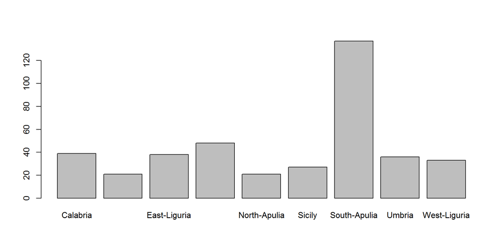

```r
barplot(table(train_labels))
```

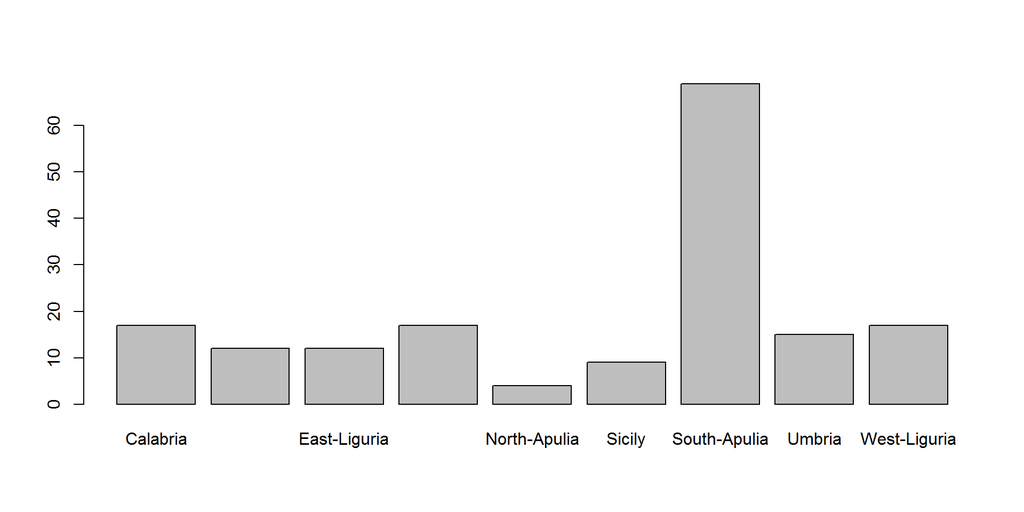

```r
barplot(table(test_labels))
```

Видно, что более менее одинаково. Построим первую модель. Как советовал Лео Брейман берем размер выборки для дерева ceiling(0.632*N), количество переменных для дерева sqrt(M), минимальное число наблюдений в узле 1 и делаем выборки для каждого дерева с повторениями. Берем количество деревьев с запасом

```r
set.seed(42)
model1<-randomForest(train,train_labels,ntree=500,mtry=3,sampsize=253,nodesize = 1,replace=T,importance = T,localImp = F,proximity = F,norm.votes = T,do.trace = 25,keep.forest = T,corr.bias = F,keep.inbag = F)
```

```
## ntree      OOB      1      2      3      4      5      6      7      8      9
##    25:   6.75% 12.82%  4.76%  7.89%  0.00%  4.76% 40.74%  3.65%  0.00%  3.03%
##    50:   5.50%  7.69%  4.76%  7.89%  0.00%  4.76% 33.33%  2.92%  0.00%  3.03%
##    75:   5.25% 12.82%  0.00%  7.89%  0.00%  4.76% 37.04%  0.73%  0.00%  3.03%
##   100:   4.75% 15.38%  0.00%  7.89%  0.00%  0.00% 29.63%  0.73%  0.00%  3.03%
##   125:   5.25% 12.82%  4.76%  7.89%  0.00%  4.76% 33.33%  0.73%  0.00%  3.03%
##   150:   5.50% 12.82%  0.00%  7.89%  0.00%  4.76% 37.04%  1.46%  0.00%  3.03%
##   175:   5.50% 12.82%  0.00%  7.89%  0.00%  4.76% 37.04%  1.46%  0.00%  3.03%
##   200:   5.25% 10.26%  4.76%  7.89%  0.00%  4.76% 33.33%  1.46%  0.00%  3.03%
##   225:   5.50% 10.26%  4.76%  7.89%  0.00%  4.76% 37.04%  1.46%  0.00%  3.03%
##   250:   5.50% 10.26%  4.76%  7.89%  0.00%  4.76% 37.04%  1.46%  0.00%  3.03%
##   275:   5.25% 10.26%  4.76%  7.89%  0.00%  4.76% 33.33%  1.46%  0.00%  3.03%
##   300:   5.50% 10.26%  4.76%  7.89%  0.00%  4.76% 37.04%  1.46%  0.00%  3.03%
##   325:   5.50% 10.26%  4.76%  7.89%  0.00%  4.76% 37.04%  1.46%  0.00%  3.03%
##   350:   5.50% 10.26%  4.76%  7.89%  0.00%  4.76% 37.04%  1.46%  0.00%  3.03%
##   375:   5.50% 10.26%  4.76%  7.89%  0.00%  4.76% 37.04%  1.46%  0.00%  3.03%
##   400:   5.25% 10.26%  4.76%  7.89%  0.00%  4.76% 33.33%  1.46%  0.00%  3.03%
##   425:   5.25% 10.26%  4.76%  7.89%  0.00%  4.76% 33.33%  1.46%  0.00%  3.03%
##   450:   5.50% 10.26%  4.76%  7.89%  0.00%  4.76% 37.04%  1.46%  0.00%  3.03%
##   475:   5.50% 10.26%  4.76%  7.89%  0.00%  4.76% 37.04%  1.46%  0.00%  3.03%
##   500:   5.50% 10.26%  4.76%  7.89%  0.00%  4.76% 37.04%  1.46%  0.00%  3.03%
```

Модель сразу показывает очень хороший результат и ошибка на отложенной выборке составляет чуть больше 5%.Как и ожидалось, можно взять гораздо меньше деревьев. Построим такую же модель но с меньшим количеством деревьев.

```r
set.seed(42)
model1_opt<-randomForest(train,train_labels,ntree=100,mtry=3,sampsize=253,nodesize = 1,replace=T,importance = T,localImp = F, proximity = F,norm.votes = T,do.trace =10,keep.forest = T,corr.bias = F,keep.inbag = F)
```

```
## ntree      OOB      1      2      3      4      5      6      7      8      9
##    10:   9.50% 15.38%  4.76% 13.16%  0.00% 28.57% 44.44%  2.92%  0.00% 12.12%
##    20:   6.50% 12.82%  0.00%  7.89%  0.00% 14.29% 33.33%  3.65%  0.00%  3.03%
##    30:   6.00% 10.26%  4.76%  7.89%  0.00%  9.52% 29.63%  2.19%  2.78%  6.06%
##    40:   5.75% 10.26%  4.76%  7.89%  0.00%  4.76% 33.33%  2.92%  0.00%  3.03%
##    50:   5.50%  7.69%  4.76%  7.89%  0.00%  4.76% 33.33%  2.92%  0.00%  3.03%
##    60:   5.50% 12.82%  0.00%  7.89%  0.00%  4.76% 33.33%  2.19%  0.00%  3.03%
##    70:   5.25% 12.82%  0.00%  7.89%  0.00%  4.76% 33.33%  0.73%  0.00%  6.06%
##    80:   5.25% 12.82%  0.00%  7.89%  0.00%  4.76% 37.04%  0.00%  0.00%  6.06%
##    90:   5.50% 12.82%  0.00%  7.89%  0.00%  4.76% 37.04%  0.73%  0.00%  6.06%
##   100:   4.75% 15.38%  0.00%  7.89%  0.00%  0.00% 29.63%  0.73%  0.00%  3.03%
```

Точность на тренировочной выборке

```r
p1_train<-predict(model1_opt,train)
sum(diag(table(p1_train,train_labels)))/sum(table(p1_train,train_labels))
```

```
## [1] 1
```

Точность на тестовой выборке

```r
p1<-predict(model1_opt,test)
sum(diag(table(p1,test_labels)))/sum(table(p1,test_labels))
```

```
## [1] 0.9476744
```

Посмотрим,какие из переменных важны.

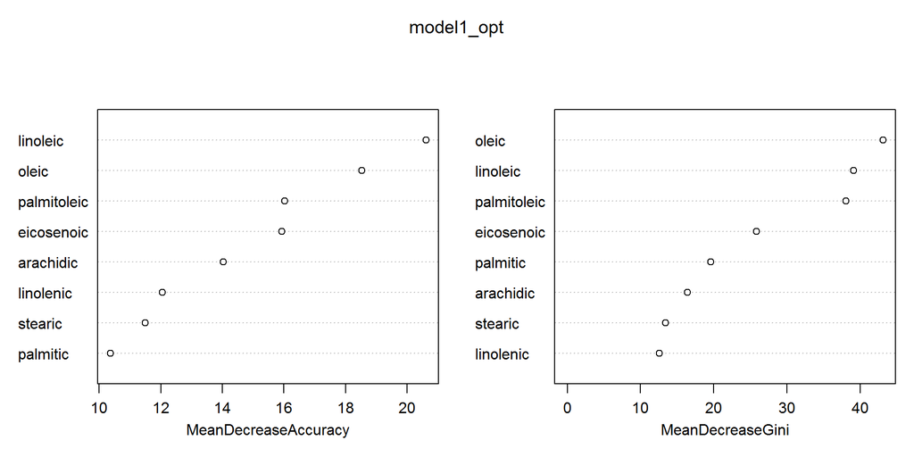

```r
varImpPlot(model1_opt)
```

Результаты немного отличаются, но в целом переменные сильно влияющие на точность сильно влияют и на индекс Джини. Можно еще посмотреть, как часто какие переменные использовались при построении леса.

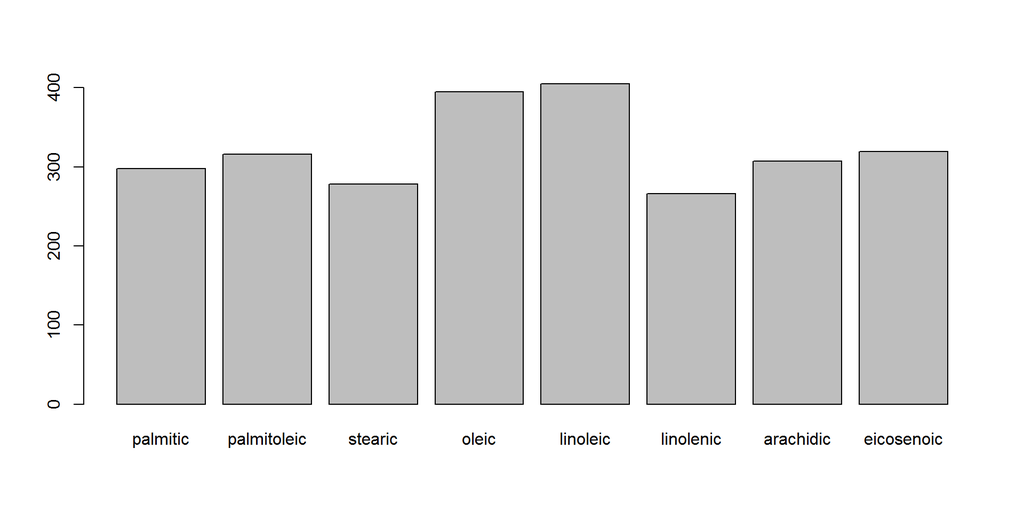

```r
using_variables<-varUsed(model1_opt, by.tree=F,count=T)
names(using_variables)<-c("palmitic","palmitoleic","stearic","oleic","linoleic","linolenic","arachidic",
"eicosenoic")
barplot(using_variables)
```

Результаты представляют собой нечто среднее между результатами предыдущих двух графиков. Но так как, на данный момент основной задачей является только предсказание, а не интерпретация результатов, а также потому, что я не очень много понимаю в маслах, не будем останавливаться на этих графиках.  
Попробуем поэксперементировать с параметрами модели. Увеличим параметр nodesize до 5.

```r
set.seed(42)
model2<-randomForest(train,train_labels,ntree=150,mtry=3,sampsize=253,nodesize = 5,replace=T,importance = T,localImp = F,proximity = F,norm.votes = T,do.trace = 15,keep.forest = T, corr.bias = F,keep.inbag = F)
```

```
## ntree      OOB      1      2      3      4      5      6      7      8      9
##    15:   7.50% 17.95%  4.76% 10.53%  0.00% 14.29% 33.33%  2.19%  0.00%  9.09%
##    30:   6.50% 10.26%  4.76% 10.53%  0.00%  4.76% 37.04%  3.65%  0.00%  3.03%
##    45:   5.75% 10.26%  4.76% 10.53%  0.00%  4.76% 37.04%  1.46%  0.00%  3.03%
##    60:   5.75% 10.26%  4.76%  7.89%  0.00%  9.52% 37.04%  1.46%  0.00%  3.03%
##    75:   6.25% 10.26%  4.76%  7.89%  0.00%  9.52% 40.74%  2.19%  0.00%  3.03%
##    90:   6.50% 10.26%  4.76%  7.89%  0.00%  9.52% 44.44%  2.19%  0.00%  3.03%
##   105:   6.50% 10.26%  4.76%  7.89%  0.00%  9.52% 44.44%  2.19%  0.00%  3.03%
##   120:   6.50% 10.26%  4.76%  7.89%  0.00%  9.52% 44.44%  2.19%  0.00%  3.03%
##   135:   6.25% 10.26%  4.76%  7.89%  0.00%  9.52% 40.74%  2.19%  0.00%  3.03%
##   150:   6.25% 10.26%  4.76%  7.89%  0.00%  9.52% 40.74%  2.19%  0.00%  3.03%
```

Точность на тренировочной выборке

```r
p2_train<-predict(model2,train)
sum(diag(table(p2_train,train_labels)))/sum(table(p2_train,train_labels))
```

```
## [1] 0.995
```

Точность на тестовой выборке

```r
p2<-predict(model2,test)
sum(diag(table(p2,test_labels)))/sum(table(p2,test_labels))
```

```
## [1] 0.9534884
```

```r
set.seed(42)
model3<-randomForest(train,train_labels,ntree=100,mtry=3,sampsize=253,nodesize = 10,replace=T,importance = T,localImp = F,proximity = F,norm.votes = T,do.trace = 15,keep.forest = T,corr.bias = F,keep.inbag = F)
```

```
## ntree      OOB      1      2      3      4      5      6      7      8      9
##    15:   8.25% 23.08%  9.52%  7.89%  0.00%  9.52% 44.44%  2.19%  2.78%  3.03%
##    30:   6.75% 23.08%  4.76%  5.26%  0.00%  9.52% 40.74%  0.73%  0.00%  3.03%
##    45:   5.50% 15.38%  4.76%  2.63%  0.00%  9.52% 40.74%  0.73%  0.00%  0.00%
##    60:   5.50% 15.38%  4.76%  2.63%  0.00%  9.52% 37.04%  0.73%  0.00%  3.03%
##    75:   6.50% 15.38%  4.76%  7.89%  0.00%  9.52% 40.74%  0.73%  2.78%  3.03%
##    90:   5.50% 12.82%  4.76%  5.26%  0.00%  4.76% 40.74%  0.73%  0.00%  3.03%
```

Точность на тренировочной выборке

```r
p3_train<-predict(model3,train)
sum(diag(table(p3_train,train_labels)))/sum(table(p3_train,train_labels))
```

```
## [1] 0.9925
```

Точность на тестовой выборке

```r
p3<-predict(model3,test)
sum(diag(table(p3,test_labels)))/sum(table(p3,test_labels))
```

```
## [1] 0.9534884
```

Теперь проанализируем ошибки.

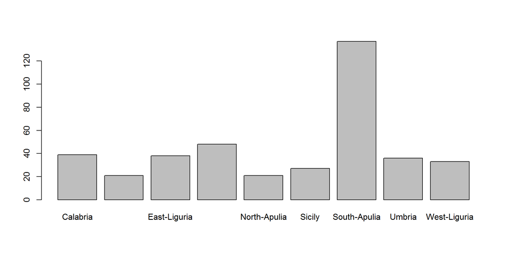

```r
barplot(table(train_labels))
```

```r
table(p1,test_labels)
```

```
##                  test_labels
## p1                Calabria Coast-Sardinia East-Liguria Inland-Sardinia
##   Calabria              17              0            0               0
##   Coast-Sardinia         0             12            0               0
##   East-Liguria           0              0           11               0
##   Inland-Sardinia        0              0            0              17
##   North-Apulia           0              0            0               0
##   Sicily                 0              0            0               0
##   South-Apulia           0              0            0               0
##   Umbria                 0              0            0               0
##   West-Liguria           0              0            1               0
##                  test_labels
## p1                North-Apulia Sicily South-Apulia Umbria West-Liguria
##   Calabria                   1      2            0      0            0
##   Coast-Sardinia             0      0            0      0            0
##   East-Liguria               0      0            0      0            0
##   Inland-Sardinia            0      0            0      0            0
##   North-Apulia               3      0            0      0            0
##   Sicily                     0      3            1      0            0
##   South-Apulia               0      4           68      0            0
##   Umbria                     0      0            0     15            0
##   West-Liguria               0      0            0      0           17
```

```r
table(train_labels)
```

```
## train_labels
##        Calabria  Coast-Sardinia    East-Liguria Inland-Sardinia
##              39              21              38              48
##    North-Apulia          Sicily    South-Apulia          Umbria
##              21              27             137              36
##    West-Liguria
##              33
```

Как видим, есть несколько областей, по которым у нас меньше данных, чем по остальным. На них мы и ошибаемся. Искусственно добавим такие наблюдения в тренировочную выборку.

```r
df_cs<-olive2[which(olive2$area=="Coast-Sardinia"),]
df_cs<-df_cs[1:20,]

df_napl<-olive2[which(olive2$area=="North-Apulia"),]
df_napl<-df_napl[1:25,]

df_sc<-olive2[which(olive2$area=="Sicily"),]
df_sc<-df_sc[1:25,]

train_labels<-c(train_labels,df_cs$area,df_napl$area,df_sc$area)
df_cs<-df_cs[,-1]
df_napl<-df_napl[,-1]
df_sc<-df_sc[,-1]

df_train1<-rbind(df_cs,df_napl,df_sc)
df_train<-rbind(train,df_train1)

train_labels<-as.factor(train_labels)
```

И построим модель по новой обучающей выборке

```r
set.seed(2016)
model1_new<-randomForest(df_train,train_labels,ntree=70,mtry=3,sampsize=292,nodesize = 1,replace=T,importance = T,localImp = F, proximity = F,norm.votes = T,do.trace =10,keep.forest = T,
corr.bias = F,keep.inbag = F)
```

```
## ntree      OOB      1      2      3      4      5      6      7      8      9
##    10:   8.30% 12.82%  2.44% 18.42%  0.00%  8.70% 21.15%  5.11%  2.78%  9.09%
##    20:   5.53%  7.69%  0.00%  7.89%  0.00%  6.52% 21.15%  3.65%  0.00%  3.03%
##    30:   5.11%  7.69%  0.00%  7.89%  0.00%  4.35% 17.31%  3.65%  0.00%  6.06%
##    40:   4.89%  7.69%  2.44% 10.53%  0.00%  2.17% 13.46%  3.65%  0.00%  6.06%
##    50:   3.62%  5.13%  0.00% 10.53%  0.00%  2.17%  9.62%  2.92%  0.00%  3.03%
##    60:   3.40%  5.13%  0.00%  7.89%  0.00%  4.35%  7.69%  2.92%  0.00%  3.03%
##    70:   3.40%  5.13%  0.00%  7.89%  0.00%  4.35%  9.62%  2.19%  0.00%  3.03%
```

Точность на тренировочной выборке

```r
p3_train<-predict(model1_new,df_train)
sum(diag(table(p3_train,train_labels)))/sum(table(p3_train,train_labels))
```

```
## [1] 1
```

Точность на тестовой выборке

```r
p3<-predict(model1_new,test)
sum(diag(table(p3,test_labels)))/sum(table(p3,test_labels))
```

```
## [1] 0.9767442
```